# First-Steps: Processing Project Data

Jake Sauter

2/17/2021

## **Context of Project FastQ Files**

Information the `fastq` files used in this study can be found [here](https://www.ncbi.nlm.nih.gov/Traces/study/?page=3&acc=PRJNA515044&o=diagnosis_sam_s%3Ad%253Bacc_s%3Bacc_s%3Aa) as well as [NCBI GEO](https://www.ncbi.nlm.nih.gov//geo/query/acc.cgi?acc=GSE125050)

**Where did you get it from?**: NCBI SRA Run Selector.

**What publication is it linked to?**: [Alzheimer’s Patient Microglia Exhibit Enhanced Aging and Unique Transcriptional Activation](https://pubmed.ncbi.nlm.nih.gov/32610143/)

**Who generated the data?**: Genentech, Inc.

**How was the RNA extracted?**:

> For whole tissue RNA studies (GSE125583), frozen tissue was sectioned in approximately 8 slices 40mm thick and stored at 80 degrees C. Tissue was homogenized in 1 mL QIAzol with 5 mm stainless steel beads using a Tissuelyzer (20 Hz for 4 min). After homogenization,200mL of choloroform were added to the cleared lysate (1 min at 12,000 rcf.at 4 degrees C), vigorously shook and incubated at room tem-perature 2-3 min. Samples were centrifuged for 15 min at 12,000 rcf.at 4 degrees C and the upper aqueous phase was transferred to a newtube. **RNA was extracted using QIAGEN miRNeasy mini columns**, yielding samples with RNA integrity (RIN) scores averaging 6.5.

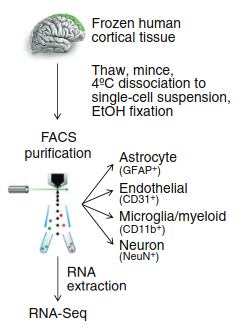

**What library prep was used?**:

> Given the highly fragmented condition of our sorted cell RNA preps, we chose the NuGEN Ovation RNA-Seq System V2 kit for cDNA synthesis since it uses random oligos for cDNA priming. We knew this would result in high percentages of intronic and non-coding RNA reads, but our priority was to sample across all exons instead of having an extreme 3’ bias and reduced complexity in our library. (Only exonic reads were counted toward nRPKM values.) Generated cDNA was sheared to 150-200bp size using LE220 ultrasonicator (Covaris). Following shearing, the size of cDNA was determined by Bioanalyzer DNA 1000 Kit (Agilent) and quantity was determined by Qubit dsDNA BR Assay (Life Technologies). Sheared cDNA was subjected to **library generation, starting at end repair step, using Illumina’s TruSeq RNA Sample Preparation Kit v2 (Illumina)**. Size of the libraries was confirmed using 4200 TapeStationand High Sensitivity D1K screen tape (Agilent Technologies) and their concentration was determined using KAPA Library Quantifi-cation kits. **The libraries were multiplexed within cell types and then sequenced on Illumina HiSeq2500 (Illumina) to generate 50M of single end 50bp reads**.

**What cell type was used?**: The cell types used in this data include Astrocytes, Endothelial cells, Microglia and Neurons.

**What was the treatment/experimental condition?**: Tissues originating from either healthy control condition brains or brains of diseased patients known to possess Alzheimer’s Disease.

**What sequencing platform was used?**: Illumina HiSeq 2500

## **Downloading the Fastq Files**

In order to first view the run accession metadata file for the fastq files of interest:

- Navigate to: https://www.ncbi.nlm.nih.gov/Traces/study/?page=3&acc=PRJNA515044&o=diagnosis_sam_s%3Ad%3Bacc_s%3Aa
- Download “metadata” file
- Run the code below to download

Since I have not found a way to do this in an automated fashion, I have downloaded the file and am hosting it myself through a Github repository made to host this assignment. Thus the **above steps do not need to be followed and the command shown below can just be run on the target system**.

```bash
mkdir accession_tables

wget https://raw.githubusercontent.com/jakesauter/Next_Gen_Sequencing_Project/main/accession_tables/Sra_run_table.txt --output-document="accession_tables/Sra_run_table.txt"
```

**Exploring the dataset**

Lets explore the distribution of experimental conditions in this dataset.

```r
library(dplyr)
library(knitr)
```

```r
filepath <- "accession_tables/Sra_run_table.txt"

df <- read.csv(filepath,
               header = TRUE,
               stringsAsFactors = FALSE) %>%
  as.data.frame()

df %>%
  group_by(Diagnosis, Cell_type) %>%
  summarise(Num_Samples=n()) %>%
  kable()
```

| Diagnosis | Cell_type | Num_Samples |
| --- | --- | --- |
| AD | astrocyte | 7 |
| AD | endothelial | 10 |
| AD | myeloid | 10 |
| AD | neuron | 21 |
| Control | astrocyte | 12 |
| Control | endothelial | 17 |
| Control | myeloid | 15 |
| Control | neuron | 21 |

We can see that the 4 main cell types are represented across control and Alzheimer’s Disease (AD). Lets choose only myeloid cells moving forward, and explore the difference in sex of collected tissues.

```r
df %>%
  filter(Cell_type == 'myeloid',
         !is.na(sex)) %>%
  group_by(Diagnosis, sex) %>%
  summarise(Num_Samples=n()) %>%
  kable()
```

| Diagnosis | sex | Num_Samples |
| --- | --- | --- |
| AD | female | 3 |
| AD | male | 5 |
| Control | female | 4 |
| Control | male | 9 |

From above we see that our smallest category for myeloid cells is AD female with a group size of 3. Moving forward, we will strive to collect 3 samples from every group for initial quality control and mapping testing.

```r
# Initially, these accession numbers were randomly sampled
# from the df data frame below with sample_n(3), though string
# literals are used now in order for this document to produce
# the same runs upon rendering
acc_nums <- c('SRR8440514', 'SRR8440538', 'SRR8440448', 'SRR8440501', 'SRR8440463', 'SRR8440477', 'SRR8440443', 'SRR8440511', 'SRR8440518', 'SRR8440482', 'SRR8440524', 'SRR8440539')


df <- df %>%
  filter(Cell_type == 'myeloid',
         !is.na(sex),
         Run %in% acc_nums) %>%
  group_by(Diagnosis, sex) %>%
  ungroup() %>%
  select("Run", "Cell_type", "sex",  "Diagnosis", "expired_age")

df %>%
  kable()
```

| Run | Cell_type | sex | Diagnosis | expired_age |
| --- | --- | --- | --- | --- |
| SRR8440477 | myeloid | male | AD | 88 |
| SRR8440501 | myeloid | male | AD | 79 |
| SRR8440511 | myeloid | female | Control | 59 |
| SRR8440518 | myeloid | female | Control | 88 |
| SRR8440443 | myeloid | female | Control | >90 |
| SRR8440448 | myeloid | female | AD | 84 |
| SRR8440482 | myeloid | male | Control | >90 |
| SRR8440514 | myeloid | female | AD | 78 |
| SRR8440524 | myeloid | male | Control | 86 |
| SRR8440538 | myeloid | female | AD | 84 |
| SRR8440539 | myeloid | male | Control | >90 |
| SRR8440463 | myeloid | male | AD | 72 |

We can then use this accession list to download our files of interest.

```bash
cell_type="myeloid_cells"
acc_nums=(SRR8440514 SRR8440538 SRR8440448 SRR8440501 SRR8440463 SRR8440477 SRR8440443 SRR8440511 SRR8440518 SRR8440482 SRR8440524 SRR8440539)

for acc_num in "${acc_nums[@]}" ; do
  fasterq-dump --outdir $cell_type $acc_num
  gzip ${cell_type}/${acc_num}.fastq
done
```

## **FastQC Quality Control**

```bash
cell_type="myeloid_cells"
fastq_files=$(ls "${cell_type}"/*.fastq.gz)
fastqc_outdir="${cell_type}_fastqc"

mkdir "${cell_type}_fastqc"

for fastq_file in $fastq_files; do
  fastqc $fastq_file --noextract \
    --outdir=$fastqc_outdir \
    --threads=12
done
```

```bash
cd $fastqc_outdir
multiqc .
```

The above command will generate a `multiqc_report.html` file which we can inspect to determine the overall quality of the sequenced libraries.

### **Per Base Sequence Quality**

Overall sequence quality of the sequenced libraries appears to be very high when view the **Per Base Sequence Quality** score in the resultant `multiqc_report.html`.

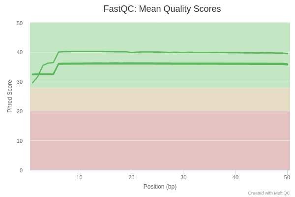

### **Over-Represented Sequences**

`MultiQC` output has also informed us about some warnings regarding over-represented sequences. Unfortunality, this sequence is not shown in `MultiQC` output, so we will inspect a `FastQC` output html file to gain more information about this. For this exercise I have chosen to view `SRR8440524_fastqc.html`, which shows us below that we may have some Illumina TruSeq Adapter dimerization contamination.

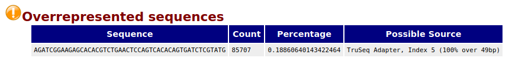

### **TrimGalore**

Due to the highly frequent over-represented sequences seen above, I have opted to try to use [`TrimGalore`](https://www.bioinformatics.babraham.ac.uk/projects/trim_galore/) on these reads to remove the potential adapter sequence.

Notice below that I did not choose to use the `--fastqc` or `--fastqc_args` parameters to `trim_galore`. I chose not to use these options as in order to parallelize `FastQC`, it must be working on multiple files at a time. Thus, in order to more efficiently make use of the system it would actually be quicker to run `FastQC` independent of `trim_galore` afterwards.

**FASTQC On Trimmed Sequences**

```bash
cell_type="myeloid_cells"
fastq_files=$(ls "${cell_type}"/*.fastq.gz)

trim_galore_outdir="trimmed_${cell_type}"
fastqc_outdir="trimmed_${cell_type}_fastqc"
mkdir $fastqc_outdir

trim_galore $fastq_files \
  --output_dir="${trim_galore_outdir}" \
  --cores 8 --phred33 --gzip

trimmed_files=$(ls $trim_galore_outdir/*.fq.gz)
fastqc $trimmed_files \
  --outdir=$fastqc_outdir \
  --threads=12 --noextract

cd $fastqc_outdir
multiqc .
```

**Trim Reports**

Below we can see that `TrimGalore` did not remove too many sequences from any one file, with the largest amount of sequences being **2.3%**, coming from sample **SRR8440443**

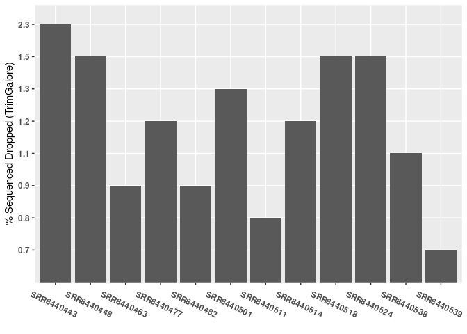

**Code for above plot**

```bash
tail -n 2 $trim_galore_outdir/*_trimming_report.txt > trimming_reports.txt
```

```r
library(stringr)
library(magrittr)
library(ggplot2)

lines <- readLines('trimming_reports.txt')
lines <- lines[lines != ""]

removed_seq_data <- vector('numeric', length(lines)/2)

for (i in seq(1,length(lines), 2)) {
  sample_name <- lines[i] %>%
    str_extract("SRR[0-9]*")
  removed_seq_percentage <- lines[i+1] %>%
    str_extract("[0-9]\\.[0-9]")
  removed_seq_data[(i+1)/2] <- removed_seq_percentage
  names(removed_seq_data)[(i+1)/2] <- sample_name
}

removed_seq_data %>%
  data.frame(Sample=names(.),
             Percent_Dropped=.,
             row.names = NULL) %>%
  ggplot(aes(x=Sample, y=Percent_Dropped)) +
    geom_col() +
    ylab("% Sequenced Dropped (TrimGalore)") +
    xlab("") +
    theme(axis.text.x=element_text(angle = -25, face='bold'),
          axis.text.y=element_text(face='bold'))
```

As well as total sequences removed, we can see that the total sequence length distribution has not been devastated after the use of `TrimGalore`, which should give us some trust that it has not removed large chunks from too many sequences.

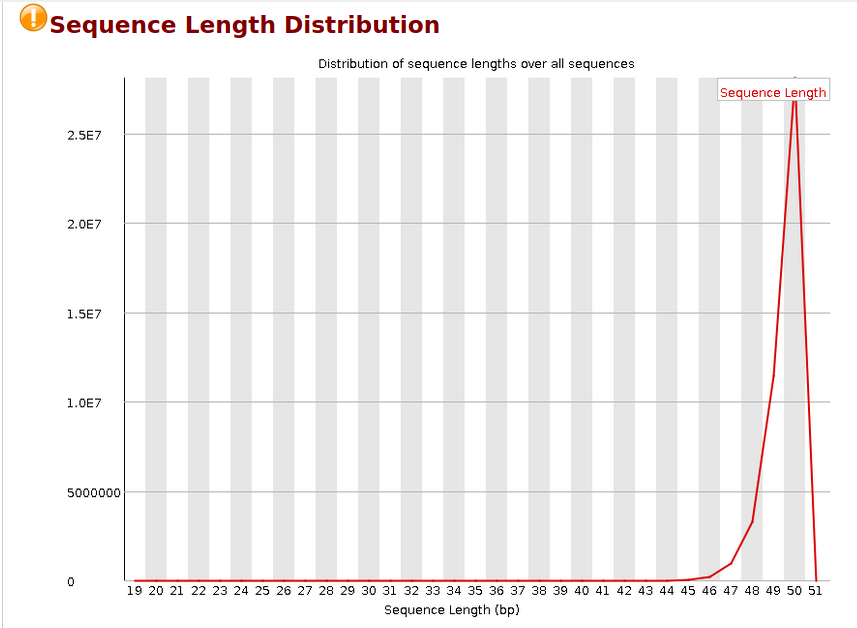

### **Per Base Sequence Content**

Some issues were spotted in the `FastQC` reports in the per base sequence content section for some of the samples. A few of the samples seem to show a cyclic pattern on this plot, indicating a potential bias or issue with the sequencing lane / tile of the sample. Unfortunately, sequencing lane and tile information is not available for this data

[Github issue showing that SRA does not store this information](https://github.com/ncbi/sra-tools/issues/130)

Particularly this issue was seen in three of the samples that I have chosen to process at this stage, with the effect occurring with varying degree. These samples were `SRR8440539`, `SRR8440524`, and `SRR8440538`.

```r
per_base_seq_off <- c('SRR8440539', 'SRR8440524', 'SRR8440538')

df %>%
  filter(Run %in% per_base_seq_off)
```

[output not shown]

We see that two of these sample are from male control samples, while one is a female AD sample, so this issue is not contained to one experimental group.

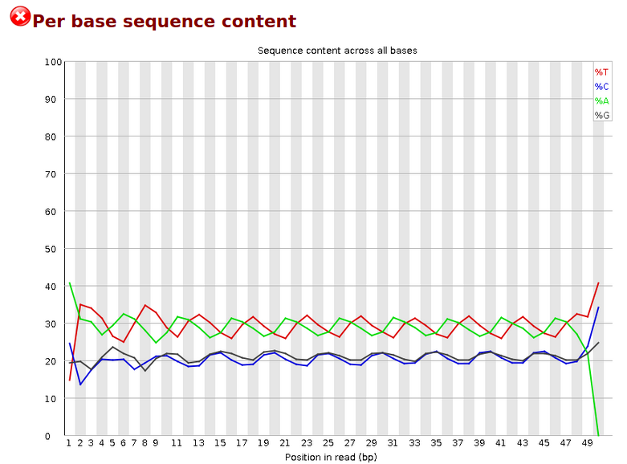

### **Per Sequence GC Content**

After trimming with `trim_galore`, we can inspect the `multiqc_report.html` generated from the previous command. Upon inspecting this file, sequence quality still remains largely high, however we see that one sequence appears to have a skewed per sequence gc content distribution. We note that this sample is `SRR8440463`, and will keep an eye on this sample.

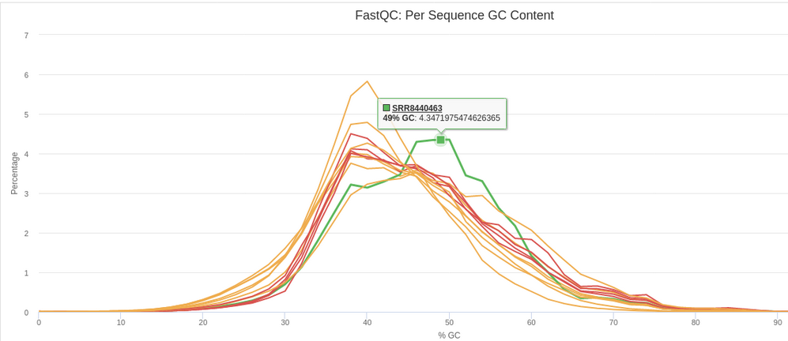

We also see that this same sample has the highest percentage of **duplicate reads**, leading us to believe more that this sample might be contaminated by other sequences that do not model the GC content of the target genome. **We note that this sample was not of concern earlier when studying the cyclic pattern per base sequence content list**.

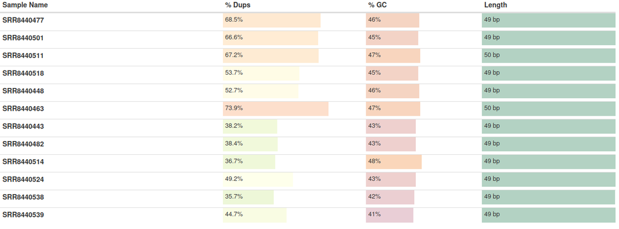

```r
df %>%
  filter(Run == "SRR8440463")
```

[output not shown]

We see that this sample is from the experimental condition (AD), thus this GC content change could be due to disease-specific modifications in the myeloid cells.